# ggplot summary

Sung

2018-06-19

## 개요

데이터 분석을 할 때 가장 먼저 해야할 일은 무엇일까? 엑셀로 분석한다면 데이터를 엑셀로 불러와서 작업하면 되겠지만, 엑셀로 통계 프로그램을 사용할 경우에는 데이터를 형태에 맞게 불러오는 것이 우선일 것이다. 필자는 오랜 기간동안 R 프로그램을 사용하고 있다. 일반적으로 책에 나온 예제 데이터는 건수가 적고 잘 정리된 형태이지만, 실제로는 그렇지 않은 경우가 많이 있다. 운이 좋으면 잘 정리된 형태일 수도 있다. 결과적으로 데이터를 불러오는 것을 못한다면 분석을 시작하기도 어려울 것이다.

데이터를 불러온 이후 데이터가 분석하기 좋은 형태인지 데이터에 오류는 없는지 확인해야 한다. 문제가 있다면 다시 추출해야 할 것이고, 문제가 없다면 분석하기 좋은 형태로 변환해야 할 것이다. 물론 교과서에서는 분석하기 좋은 형태로 변환되어진 데이터를 제공할 것이다. 데이터를 불러왔다면 그 다음 단계로 중요한 것은 데이터를 탐색하는 과정(EDA)이다. 데이터를 탐색하는 과정에서는 요약 통계량이나 차트 형태로 데이터의 정합성을 검증하거나 데이터의 특징을 파악한다. 대부분 분석가들의 업무 프로세스를 보면 분석의 80~90%는 데이터 검증 및 전처리에 소요된다.

이 문서에서는 분석하기 좋은 형태의 데이터를 가지고 시각화하는 내용을 정리하려고 한다. 내용을 정리하는 가장 중요한 이유는 내가 쓰고 싶은 차트를 작성할 때마다 옵션이 기억안나니 너무 불편해서 정리하려고 한다. 차트는 R의 `ggplot2` 패키지를 활용하여 작성한다.

## 데이터 소개

모든 데이터는 잘 불러왔다는 가정하에 `ggplot2` 패키지의 `diamonds` 데이터를 사용할 것이다. 이 데이터는 조금 정리해보자..

```r
diamonds
##> # A tibble: 53,940 x 10
##>    carat cut       color clarity depth table price     x     y     z
##>    <dbl> <ord>     <ord> <ord>   <dbl> <dbl> <int> <dbl> <dbl> <dbl>
##>  1 0.23  Ideal     E     SI2      61.5    55   326  3.95  3.98  2.43
##>  2 0.21  Premium   E     SI1      59.8    61   326  3.89  3.84  2.31
##>  3 0.23  Good      E     VS1      56.9    65   327  4.05  4.07  2.31
##>  4 0.290 Premium   I     VS2      62.4    58   334  4.2   4.23  2.63
##>  5 0.31  Good      J     SI2      63.3    58   335  4.34  4.35  2.75
##>  6 0.24  Very Good J     VVS2     62.8    57   336  3.94  3.96  2.48
##>  7 0.24  Very Good I     VVS1     62.3    57   336  3.95  3.98  2.47
##>  8 0.26  Very Good H     SI1      61.9    55   337  4.07  4.11  2.53
##>  9 0.22  Fair      E     VS2      65.1    61   337  3.87  3.78  2.49
##> 10 0.23  Very Good H     VS1      59.4    61   338  4     4.05  2.39
##> # ... with 53,930 more rows
```

## 연속형

### 1-dimension

`Histogram`은 연속형 데이터의 분포를 나타내는 차트로, 생성되는 bar의 개수(`bins` 옵션)나 bar의 길이(`binwidth` 옵션)를 지정할 수 있다. y축은 구간에 해당하는 건수이다.

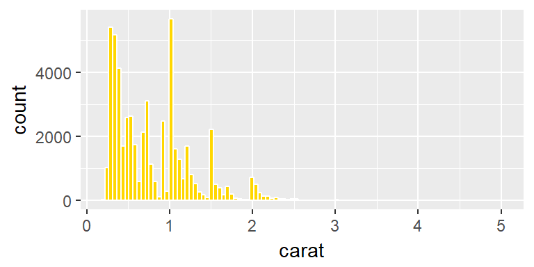

```r
diamonds %>%
    ggplot(aes(x = carat)) +
    geom_histogram(fill = "gold", color = "white", bins = 100)
```

`Density`는 연속형 데이터의 분포를 나타내는 차트로 y축은 desity이다.

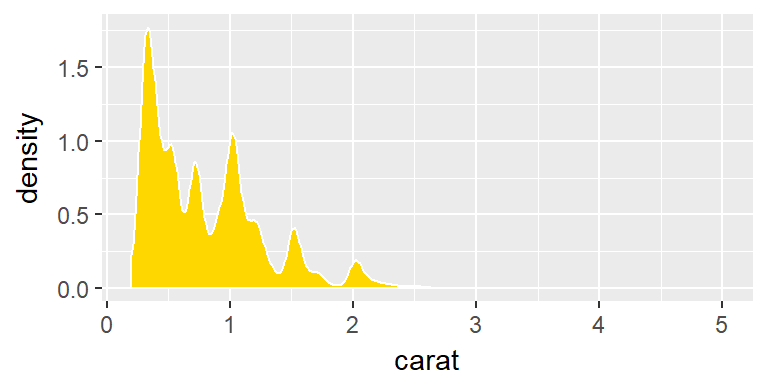

```r
diamonds %>%
    ggplot(aes(x = carat)) +
    geom_density(fill = "gold", color = "white")
```

`Freqploy`는 연속형 데이터의 분포를 나타내는 차트로 y축은 건수이다.

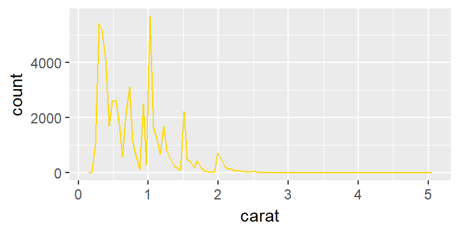

```r
diamonds %>%
    ggplot(aes(x = carat)) +
    geom_freqpoly(color = "gold", bins = 100)
```

`scatter plot`은 1차원인 경우 x축이 index 값인 점 차트를 생성한다. 대부분 시계열 데이터를 시각화할 때 주로 쓰인다. 점이 아닌 선의 경우 `geom_line()`함수를 사용한다.

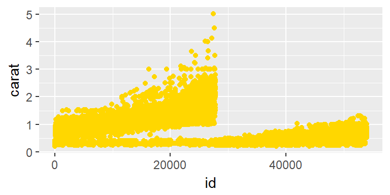

```r
diamonds %>%
    mutate(id = 1:n()) %>%
    ggplot(aes(x = id, y = carat)) +
    geom_point(color = "gold")
```

### 2-dimension

`scatter plot`은 x축과 y축에 해당하는 위치에 점 차트를 생성한다.  
점이 아닌 선의 경우 `geom_line()`함수를 사용한다.

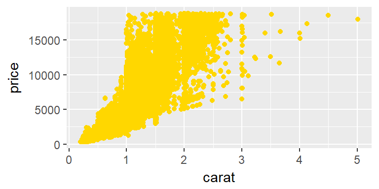

```r
diamonds %>%
    ggplot(aes(x = carat, y = price)) +
    geom_point(color = "gold")
```

`scatter plot`에 색상 legend를 추가하여 2차원 그래프를 그릴 수 있다.

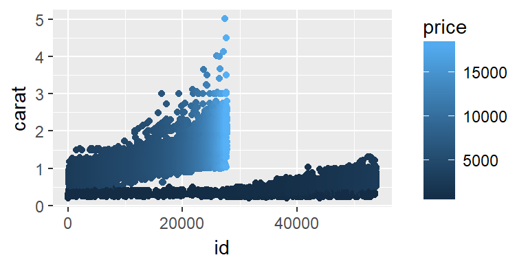

```r
diamonds %>%
    mutate(id = 1:n()) %>%
    ggplot(aes(x = id, y = carat)) +
    geom_point(aes(color = price))
```

### 3-dimension

2차원 `scatter plot`에 색상 legend를 추가하여 3차원 그래프를 그릴 수 있다.

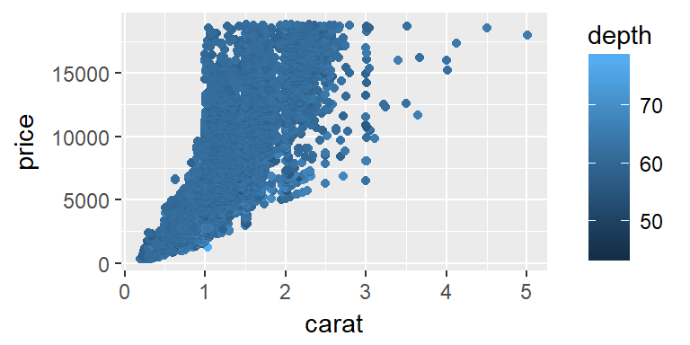

```r
diamonds %>%
    ggplot(aes(x = carat, y = price)) +
    geom_point(aes(color = depth))
```

`contour plot`으로 3차원 그래프를 그릴 수 있다.

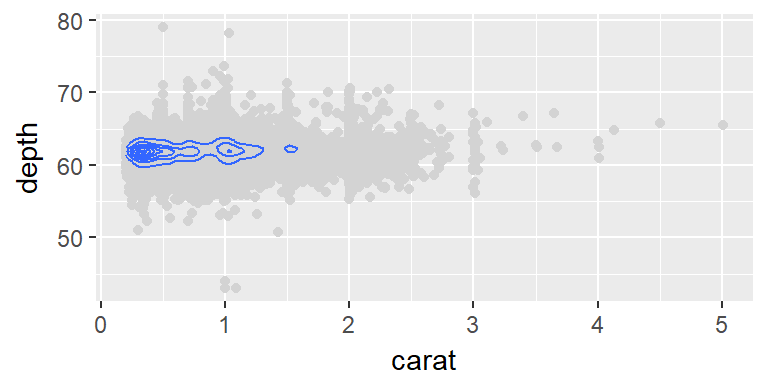

```r
#https://tdhock.github.io/animint/
diamonds %>%
    ggplot(aes(x = carat, y = depth)) +
    geom_point(color = "lightgray") +
    geom_density_2d()
```

## 이산형

### 1-dimension

`Bar plot`에 이산형 변수에 해당하는 데이터 건수를 막대 그래프로 생성한다.

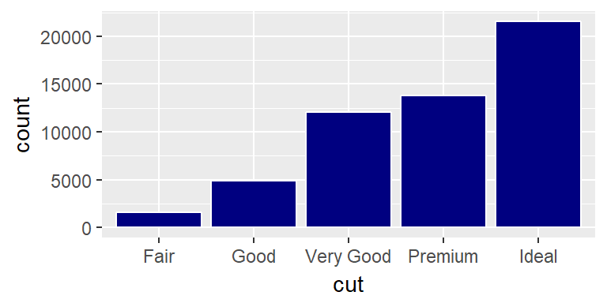

```r
diamonds %>%
    ggplot(aes(x = cut)) +
    geom_bar(color = "white", fill = "navyblue")
```

아래와 같이 건수를 출력한 이후에도 `bar plot`을 생성할 수 있다.

```r
diamonds %>%
    group_by(cut) %>%
    summarise(cnt = n()) %>%
    ggplot(aes(x = cut)) +
    geom_bar(aes(y = cnt), stat = "identity", color = "white", fill = "navyblue")
```

[output not shown]

### 2-dimension

`Bar plot`에 색상 legend를 추가하여 2차원 그래프를 그릴 수 있다.

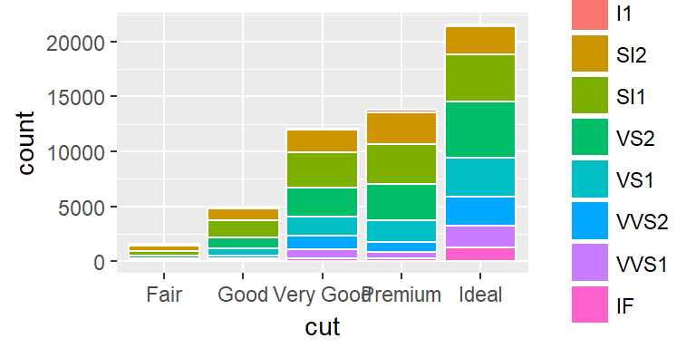

```r
diamonds %>%
    ggplot(aes(x = cut, fill = clarity)) +
    geom_bar(color = "white")
```

`Mosaic plot`은 이산형 변수에 해당하는 데이터 건수의 비율을 막대의 넓이와 색상으로 구분하여 보여준다.

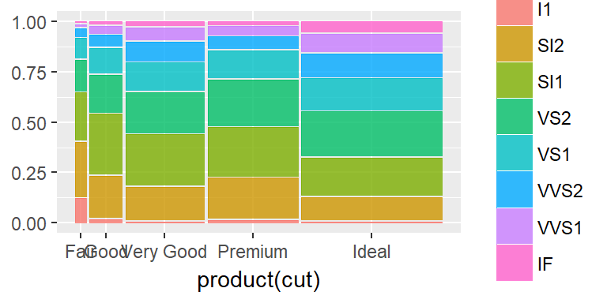

```r
library(ggmosaic)
diamonds %>%
    ggplot(aes(x = product(cut), fill = clarity)) +
    geom_mosaic()
```

### 3-dimension

색상 legend를 추가하여 2차원 공간에 3차원으로 시각화 할 수 있다.

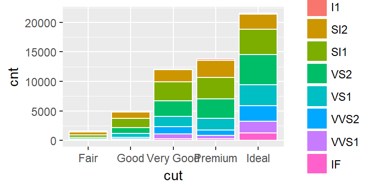

```r
diamonds %>%
    group_by(cut, clarity) %>%
    summarise(cnt = n()) %>%
    ggplot(aes(x = cut, fill = clarity)) +
    geom_bar(aes(y = cnt), stat = "identity", color = "white")
```

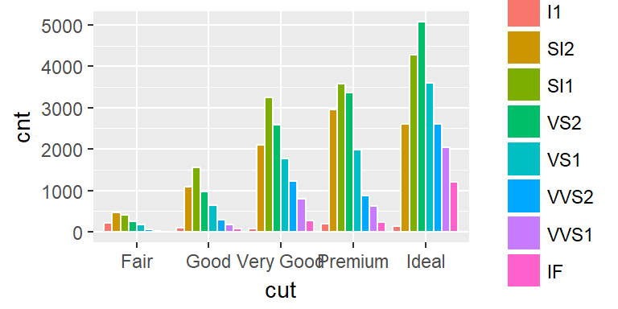

```r
diamonds %>%
    group_by(cut, clarity) %>%
    summarise(cnt = n()) %>%
    ggplot(aes(x = cut, fill = clarity)) +
    geom_bar(aes(y = cnt), stat = "identity", color = "white", position = "dodge")
```

## 조합 (이산형, 연속형)

### 3-dimension

2차원 연속형 plot에 이산형 색상 legend를 추가하여 3차원 그래프를 그릴 수 있다. (단, 이산형의 경우 막대 차트에 연속형으로 색상을 입력하는 것은 불가함)

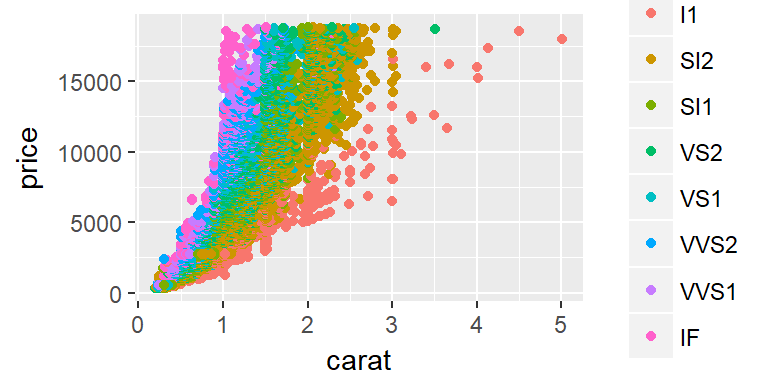

```r
diamonds %>%
    ggplot(aes(x = carat, y = price)) +
    geom_point(aes(color = clarity))
```

## 연속형을 이산형으로 바꾸기

`cut()`함수를 사용하여 연속형 변수를 이산형(`factor`)으로 바꾸고 `label`도 입력할 수 있다.

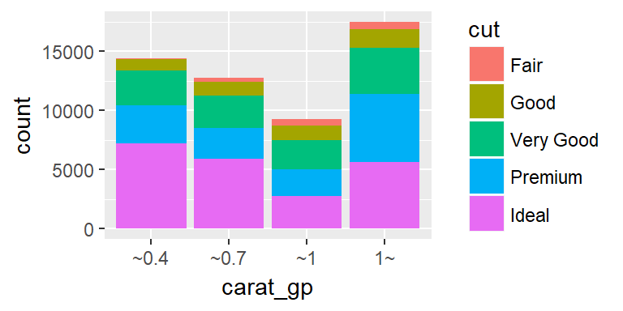

```r
diamonds %>%
    mutate(carat_gp = cut(carat, breaks = c(0, 0.4, 0.7, 1, Inf),
                          ordered_result = T, labels = c("~0.4", "~0.7", "~1", "1~"))) %>%
    ggplot(aes(x = carat_gp, fill = cut)) +
    geom_bar()
```

## 차트 옵션

### legend

`ggplot()`에서는 `fill` 이나 `color` 옵션이 `aes()`함수 안에 존재하게 되는 경우 `legend`가 생성되는데 이를 없애기 위해 `show.legend = F`옵션을 추가할 수 있다.

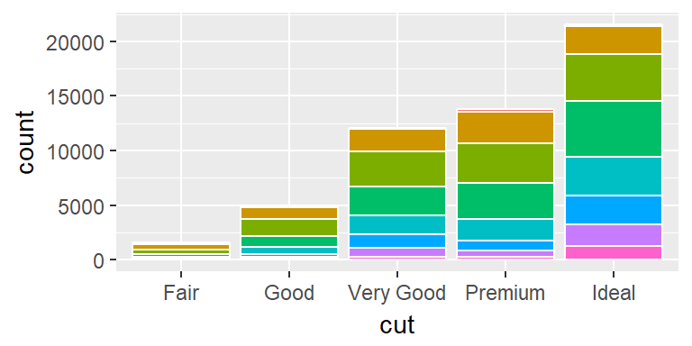

```r
diamonds %>%
    ggplot(aes(x = cut, fill = clarity)) +
    geom_bar(color = "white", show.legend = F)
```

### multiple plot

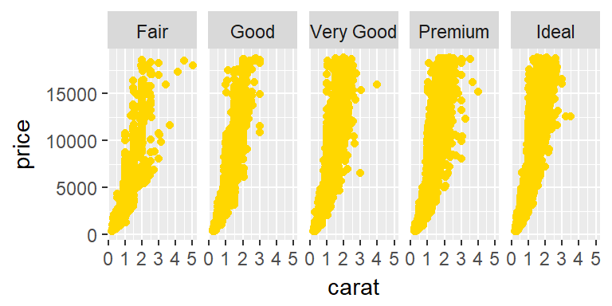

```r
diamonds %>%
    ggplot(aes(x = carat, y = price)) +
    geom_point(color = "gold") +
    facet_grid(. ~ cut)
```

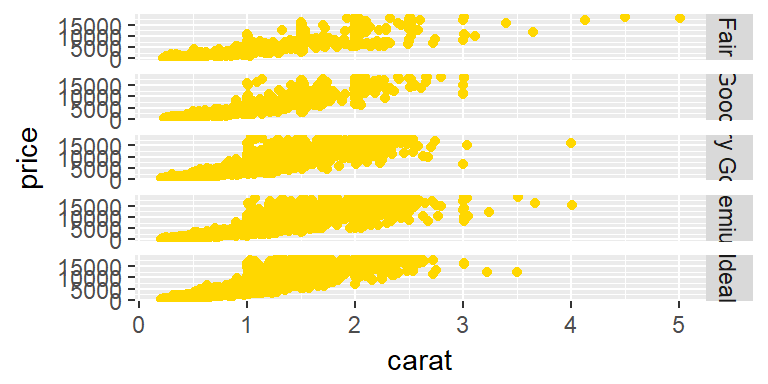

```r
diamonds %>%
    ggplot(aes(x = carat, y = price)) +
    geom_point(color = "gold") +
    facet_grid(cut ~ .)
```

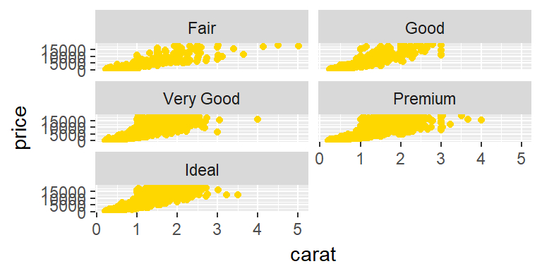

```r
diamonds %>%
    ggplot(aes(x = carat, y = price)) +
    geom_point(color = "gold") +
    facet_wrap(~cut, ncol = 2)
```

다중 차트에 있는 항목명의 크기, 바탕색 등 변경 가능하다.

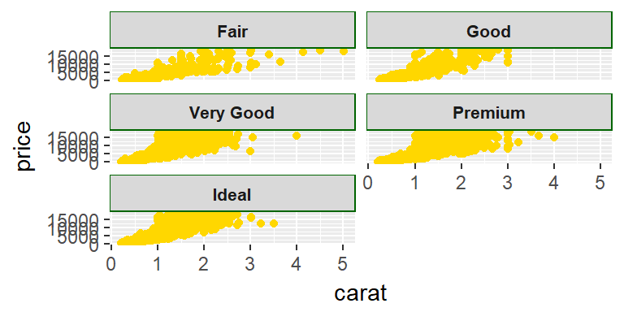

```r
diamonds %>%
    ggplot(aes(x = carat, y = price)) +
    geom_point(color = "gold") +
    facet_wrap(~cut, ncol = 2) +
    theme(strip.text.x = element_text(size = 8, face = "bold"),
          strip.background = element_rect(color = "darkgreen"))
```

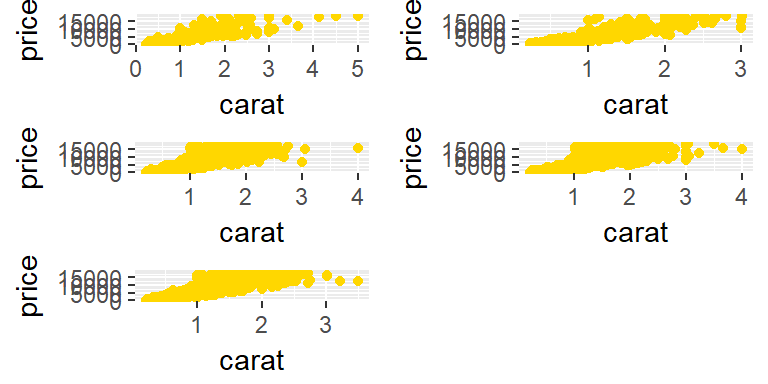

```r
g1 <- diamonds %>%
    filter(cut == "Fair") %>%
    ggplot(aes(x = carat, y = price)) +
    geom_point(color = "gold")

g2 <- diamonds %>%
    filter(cut == "Good") %>%
    ggplot(aes(x = carat, y = price)) +
    geom_point(color = "gold")

g3 <- diamonds %>%
    filter(cut == "Very Good") %>%
    ggplot(aes(x = carat, y = price)) +
    geom_point(color = "gold")

g4 <- diamonds %>%
    filter(cut == "Premium") %>%
    ggplot(aes(x = carat, y = price)) +
    geom_point(color = "gold")

g5 <- diamonds %>%
    filter(cut == "Ideal") %>%
    ggplot(aes(x = carat, y = price)) +
    geom_point(color = "gold")

library(gridExtra)
grid.arrange(g1, g2, g3, g4, g5, ncol = 2)
```

### color

차트의 형태에 따라서 `color`이나 `fill` 옵션을 사용한다. 연속형이나 이산형 모두 사용이 가능하다.

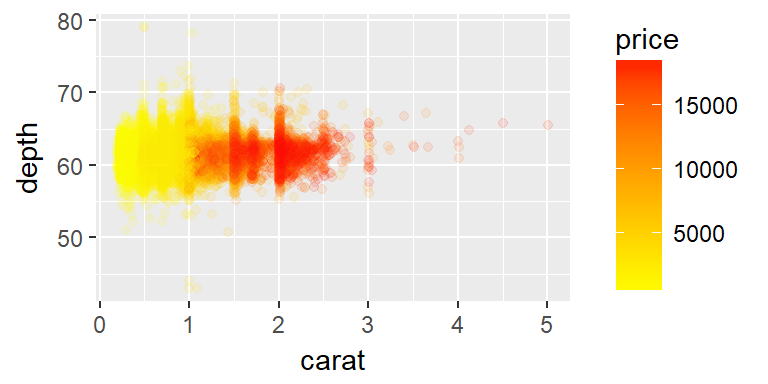

```r
diamonds %>%
    ggplot(aes(x = carat, y = depth, color = price)) +
    geom_point(alpha = 0.1) +
    scale_color_gradient(low = "yellow", high = "red")
```

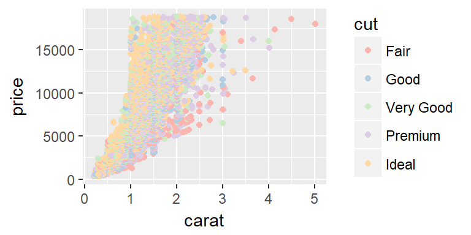

```r
diamonds %>%
    ggplot(aes(x = carat, y = price, color = cut)) +
    geom_point(aes(color = cut)) +
    scale_color_brewer(type = "qual", palette = 4)
```

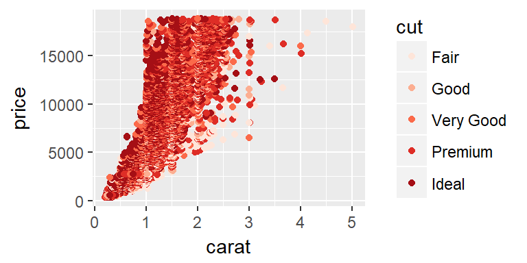

```r
diamonds %>%
    ggplot(aes(x = carat, y = price, color = cut)) +
    geom_point(aes(color = cut)) +
    scale_color_brewer(type = "seq", palette = "Reds")
```

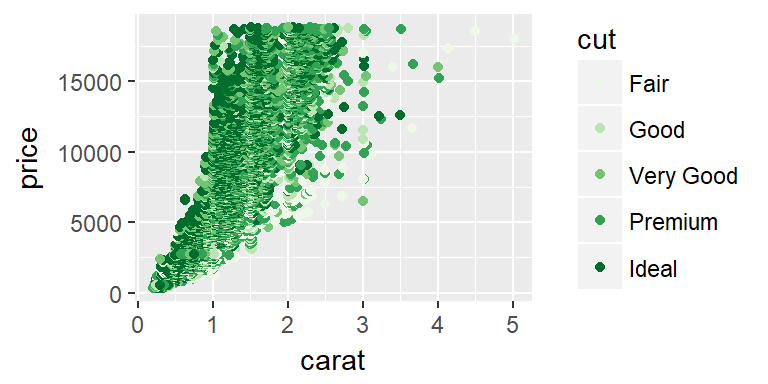

```r
diamonds %>%
    ggplot(aes(x = carat, y = price, color = cut)) +
    geom_point(aes(color = cut)) +
    scale_color_brewer(type = "seq", palette = "Greens")
```

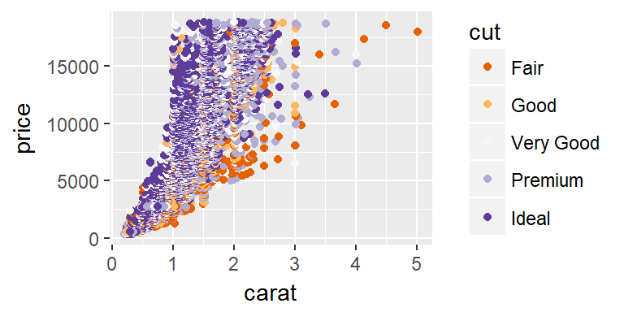

```r
diamonds %>%
    ggplot(aes(x = carat, y = price, color = cut)) +
    geom_point(aes(color = cut)) +
    scale_color_brewer(type = "div", palette = 4)
```

### legend, label, title

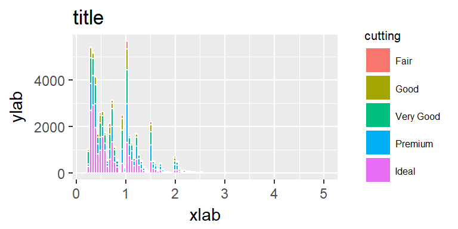

```r
diamonds %>%
    ggplot(aes(x = carat, fill = cut)) +
    geom_histogram(color = "white", bins = 100) +
    guides(col = guide_legend(ncol = 1)) +
    theme(legend.title = element_text(size = 8),
          legend.text = element_text(size = 6)) +
    labs(x = "xlab",
         y = "ylab",
         title = "title",
         fill = "cutting")
```

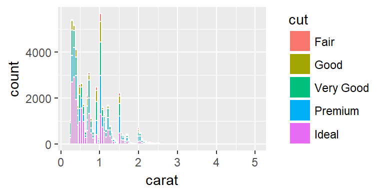

```r
diamonds %>%
    ggplot(aes(x = carat, fill = cut)) +
    geom_histogram(color = "white", bins = 100) +
    guides(col = guide_legend(ncol = 1))
```

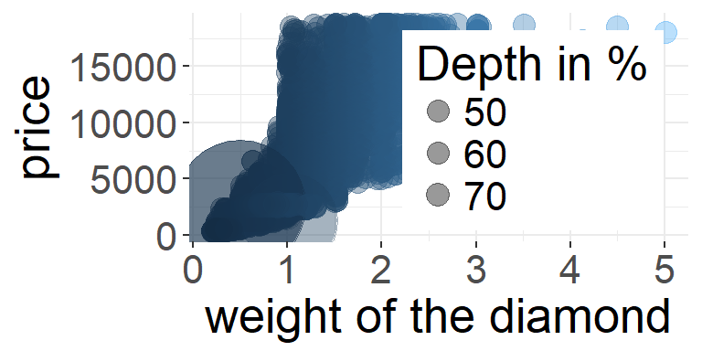

```r
diamonds %>%
    ggplot(aes(x = carat, y = price, size = depth, color = carat)) +
    geom_point(alpha = 0.4) +
    scale_size_continuous(trans = "exp", range = c(4, 25)) +
    scale_colour_continuous(guide = FALSE) +
    xlab("weight of the diamond") +
    labs(size = "Depth in %" ) +
    theme_bw() +
    theme(text = element_text(size = 20),
          legend.position = c(.95, .05),
          legend.justification = c("right", "bottom"),
          panel.border = element_blank())
```